# Peer-graded assignment

Arun K

17/08/2020

## REPORT OF THE PEER_GRADED ASSIGNMENT

For this assignment, after extracting the .csv file, it is necessary to read and clean the file till we get an optimal data frame.

```r
library(ggplot2)
library(dplyr)
library(lubridate)
act<-read.csv("activity.csv")
```

### Plot of the sum of steps taken for each day

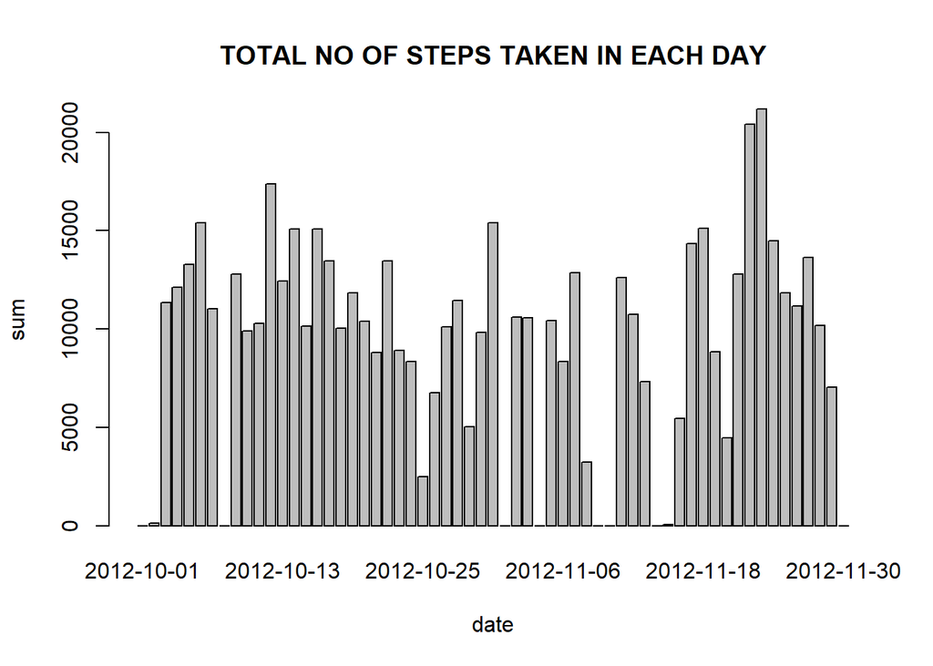

```r
sum.step<-act%>%
  group_by(date)%>%
  summarise(sum(steps,na.rm = TRUE))
names(sum.step)<-c("date","sum")
barplot(sum~date,sum.step,main="TOTAL NO OF STEPS TAKEN IN EACH DAY")
```

## What is mean total number of steps taken per day?

### About the Mean and Median

```r
mean.step<-act%>%
  group_by(date)%>%
  summarise(mean(steps,na.rm = TRUE))
median.step<-act%>%
  group_by(date)%>%
  summarise(median(steps,na.rm = TRUE))
```

#### Data Frame showing Mean and Median

```r
mean.step
```

```
## # A tibble: 61 x 2
##    date       `mean(steps, na.rm = TRUE)`
##    <chr>                            <dbl>
##  1 2012-10-01                     NaN
##  2 2012-10-02                       0.438
##  3 2012-10-03                      39.4
##  4 2012-10-04                      42.1
##  5 2012-10-05                      46.2
##  6 2012-10-06                      53.5
##  7 2012-10-07                      38.2
##  8 2012-10-08                     NaN
##  9 2012-10-09                      44.5
## 10 2012-10-10                      34.4
## # ... with 51 more rows
```

```r
median.step
```

```
## # A tibble: 61 x 2
##    date       `median(steps, na.rm = TRUE)`
##    <chr>                              <dbl>
##  1 2012-10-01                            NA
##  2 2012-10-02                             0
##  3 2012-10-03                             0
##  4 2012-10-04                             0
##  5 2012-10-05                             0
##  6 2012-10-06                             0
##  7 2012-10-07                             0
##  8 2012-10-08                            NA
##  9 2012-10-09                             0
## 10 2012-10-10                             0
## # ... with 51 more rows
```

## What is the average daily activity pattern?

### Time plot of Intervals vs Average steps

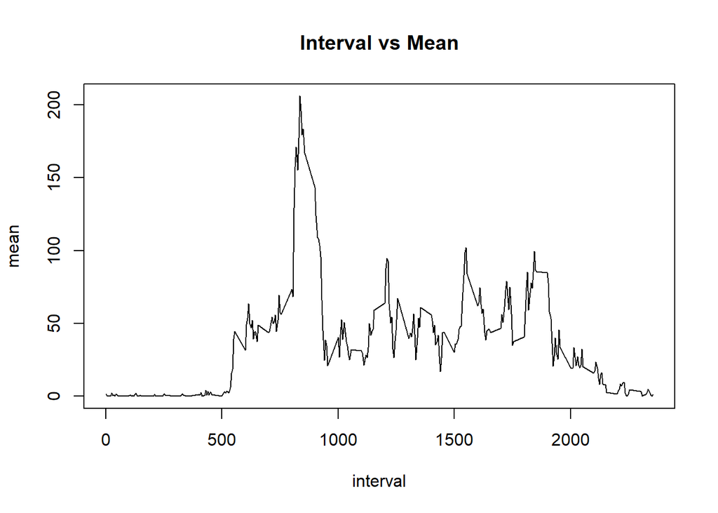

```r
avg<-act%>%
  group_by(interval)%>%
  summarise(mean(steps,na.rm=TRUE))
names(avg)<-c("interval","mean")
plot(mean~interval,avg,type="l",main="Interval vs Mean")
```

### The interval that has the maximum average value`

```r
max<-max(avg$mean)
tab<-filter(avg, mean==max)
```

The Interval that has the maximum average value is 835

## Imputing missing values

Note that there are a number of days/intervals where there are missing values (coded as NA). The presence of missing days may introduce bias into some calculations or summaries of the data.

### 1. Calculate and report the total number of missing values in the dataset (i.e. the total number of rows with NAs)

```r
na<-is.na(act$steps)
na.sum<-sum(na)
```

Total number of missing values in the dataset is 2304

### 2. Devise a strategy for filling in all of the missing values in the dataset. The strategy does not need to be sophisticated. For example, you could use the mean/median for that day, or the mean for that 5-minute interval, etc.

Filling the missing values with the mean of the steps

```r
average<-mean(act$steps,na.rm = T)
average
```

```
## [1] 37.3826
```

```r
new.act<-act
new.act$steps[na]<-average
```

### 3. Create a new dataset that is equal to the original dataset but with the missing data filled in.

new.act is the new dataset that is equal to the original dataset without any missing value

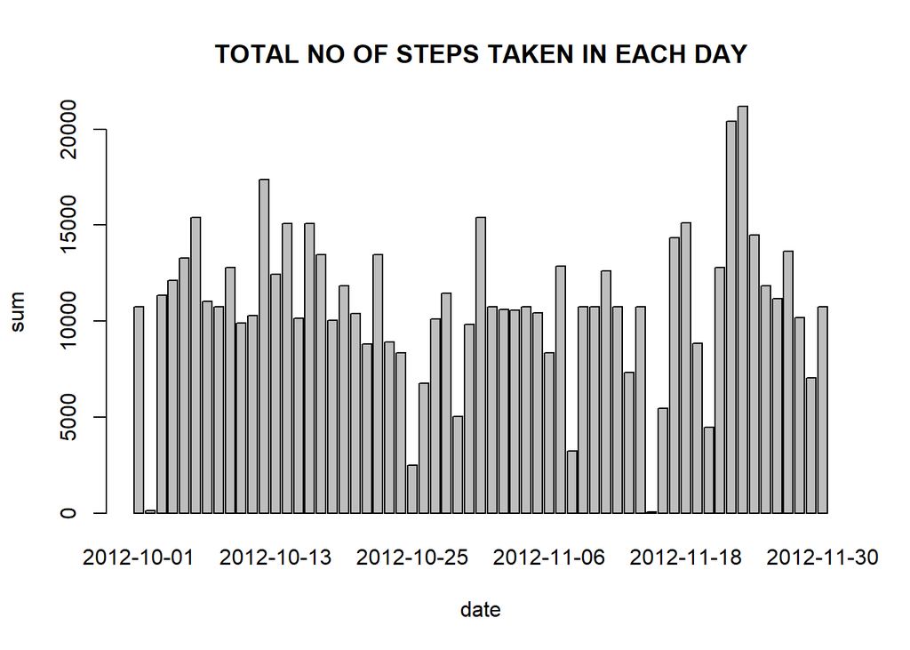

```r
sum.step2<-new.act%>%
  group_by(date)%>%
  summarise(sum(steps,na.rm = TRUE))
names(sum.step2)<-c("date","sum")
barplot(sum~date,sum.step2,main="TOTAL NO OF STEPS TAKEN IN EACH DAY")
```

#### Showing the new mean and median of new.act

```r
mean.step2<-new.act%>%
  group_by(date)%>%
  summarise(mean(steps,na.rm = TRUE))
names(mean.step2)<-c("date","steps")
median.step2<-new.act%>%
  group_by(date)%>%
  summarise(median(steps,na.rm = TRUE))
```

#### Data Frame showing Mean and Median

```r
mean.step2
```

```
## # A tibble: 61 x 2
##    date        steps
##    <chr>       <dbl>
##  1 2012-10-01 37.4
##  2 2012-10-02  0.438
##  3 2012-10-03 39.4
##  4 2012-10-04 42.1
##  5 2012-10-05 46.2
##  6 2012-10-06 53.5
##  7 2012-10-07 38.2
##  8 2012-10-08 37.4
##  9 2012-10-09 44.5
## 10 2012-10-10 34.4
## # ... with 51 more rows
```

```r
median.step2
```

```
## # A tibble: 61 x 2
##    date       `median(steps, na.rm = TRUE)`
##    <chr>                              <dbl>
##  1 2012-10-01                          37.4
##  2 2012-10-02                           0
##  3 2012-10-03                           0
##  4 2012-10-04                           0
##  5 2012-10-05                           0
##  6 2012-10-06                           0
##  7 2012-10-07                           0
##  8 2012-10-08                          37.4
##  9 2012-10-09                           0
## 10 2012-10-10                           0
## # ... with 51 more rows
```

## Are there differences in activity patterns between weekdays and weekends?

### For this part the weekdays() function may be of some help here. Use the dataset with the filled-in missing values for this part.

```r
wd<-wday(as.Date(new.act$date))
weekend<-new.act%>%
  mutate(day=wd)%>%
  filter(day==1|day==7)
weekday<-new.act%>%
  mutate(day=wd)%>%
  filter(day!=1&day!=7)
```

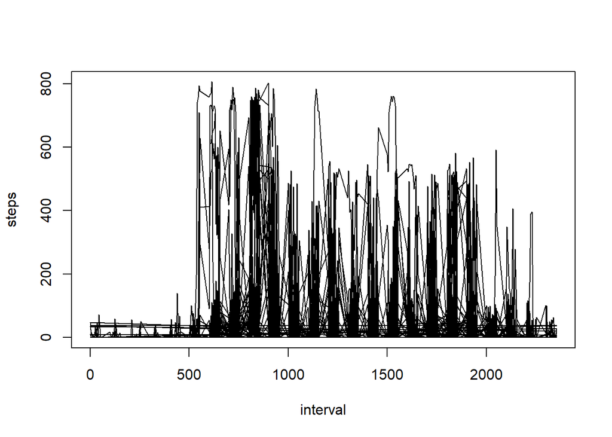

```r
plot(steps~interval,weekday,type="l")
```

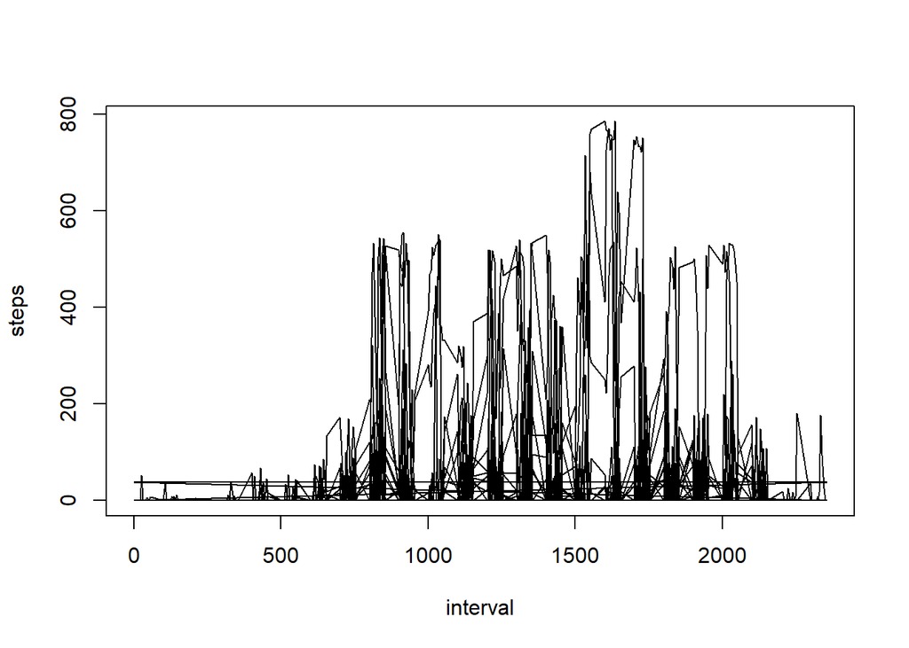

```r
plot(steps~interval,weekend,type="l")
```